# HW02-P2 Adv Data Viz

## Instructions

**Task:** Open up the New York Times article [A Summer of Strikes](https://www.nytimes.com/interactive/2023/09/03/business/economy/strikes-union-sag-uaw.html), and scroll down to the plot titled “Union membership has fallen sharply over the past four decades (Share of the work force in a union, by industry)”.

[figure not shown]

Using `ggplot2` and other tools in R, recreate this plot. Note that you will need to create the data underlying the plot yourself. You can create this data in R with `tibble()`. You can also write the data in Excel or Google Sheets and export it as a CSV file.

**Requirements:**

- Overall
  - Panels for “All workers”, “By Sector”, and “By Industry” are shown.
  - Arrows showing the change from 1983 to 2022 are shown.
    - Note: be sure that the arrows all point in the correct direction!
  - The actual percentages in 1983 and 2022 are shown as text.
  - X-axis tick marks are at 0, 25, and 50.
  - Plot title says “Union membership has fallen sharply over the past four decades”.
  - Plot subtitle says “Share of the work force in a union, by industry”.
- Resource reflection
  - At least 1 resource is listed
  - At least 3 sentences about resources and their helpfulness in the task

**Bonus**: Additional possibilities to enhance your visualization include adjusting the default aesthetics of the arrows, aligning your plots neatly, and adding margins in order to left-align the y-axis text.

## Setup

```r
library(tidyverse)
```

```r
union <- tibble(
  group = c("", rep("BY SECTOR", 2), rep("BY INDUSTRY", 10)),
  category = c(
    "All workers",
    "Private sector", "Public sector",
    "Transportation and utilities", "Manufacturing", "Mining",
    "Construction", "Education and health",
    "Arts, entertainment and recreation", "Business services",
    "Retail, food and hospitality", "Public administration", "Agriculture"
  ),
  share_1983 = c(20, 17, 37, 47, 28, 27, 28, 26, 17, 10, 8, 30, 4),
  share_2022 = c(10,  6, 33, 16,  8,  7, 13, 17,  7,  3, 3, 28, 5)
) |>
  mutate(
    group    = fct_inorder(group),
    category = fct_rev(fct_inorder(category)),
    dir      = sign(share_2022 - share_1983)
  )
```

## Visualization

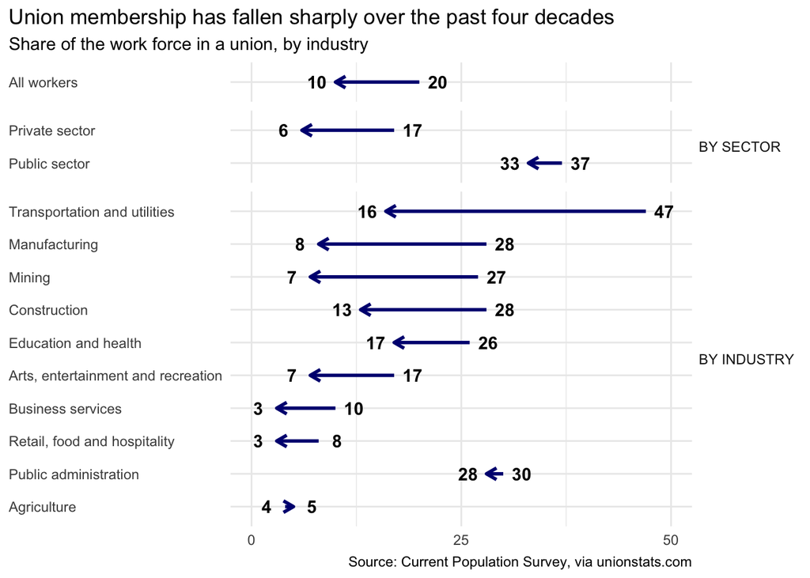

```r
ggplot(union, aes(y = category)) +
  geom_segment(
    aes(x = share_1983, xend = share_2022, yend = category),
    color = "navyblue", linewidth = 1,
    arrow = arrow(length = unit(0.1, "in"), type = "open")
  ) +
  # 1983 label sits beyond the tail, 2022 label beyond the arrowhead
  geom_text(aes(x = share_1983 - dir * 2.2, label = share_1983), fontface = "bold") +
  geom_text(aes(x = share_2022 + dir * 2.2, label = share_2022), fontface = "bold") +
  facet_grid(group ~ ., scales = "free_y", space = "free_y") +
  scale_x_continuous(breaks = c(0, 25, 50)) +
  coord_cartesian(xlim = c(0, 50), clip = "off") +
  labs(
    title    = "Union membership has fallen sharply over the past four decades",
    subtitle = "Share of the work force in a union, by industry",
    caption  = "Source: Current Population Survey, via unionstats.com",
    x = NULL, y = NULL
  ) +
   theme_minimal() +
   theme(
     plot.title.position = "plot",
    strip.text.y        = element_text(angle = 0, hjust = 0, face = "plain"),
    axis.text.y         = element_text(hjust = 0)
  )
```

## Resources Reflection (required)

List the resources you used to help with this assignment then write 3-5 sentence reflection on which resources were most helpful in finishing this task.

**Resources:**

- ica 3
- ggplot documentation
- tibble documentation

**Reflection:**

I initially struggled with bringing in the dataset through a csv file, so I switched over to the tibble method. I applied the tibble documentation to create the union dataset. Finally I used the ica to reflect on what ggplot techniques I used effectively to complete this remodel of the nyt visual.